# Índice

### Agora com esses dados podemos calcular o F1 Score, o recall e a precisão. Vale lembrar que a soma dos valores deve ser igual ao número total de clientes.

- **Fórmulas:**
- **Acurácia = (vp + vn) / (vp + fn + vn + fp)**
- **Recall(Sensibilidade) = recall = vp / (vp + fn)**
- **Especificiade = vn / (vn + fp)**
- **Precisão = vp / (vp + fp)**
- **f1 = 2 *((precisão* recall) / (precisão + recall))**

```python
# Classe que nos interessa = 1
vp = 1429
fn = 608
fp = 2451
vn = 5512
```

```python
def metricas(vp,fn,fp,vn):
    acc = round((vp + vn) / (vp + fn + vn + fp),2)
    recall = round(vp / (vp + fn),2)
    precision = round(vp / (vp + fp),2)
    f1 = 2 * round((precision * recall) / (precision + recall),2)
    return(print(f'*****Métricas*****\n\nAcurácia:{acc}\nRecall:{recall}\nPrecisão:{precision}\nF1:{f1}\n'))
```

```python
metricas(vp,fn,fp,vn)
```

```
*****Métricas*****

Acurácia:0.69
Recall:0.7
Precisão:0.37
F1:0.48
```

- **Conclusão:**
- Dentro do filtro de clientes com idade entre 40 e 70 anos, temos uma lista de 3880 clientes. 38,8% de toda a base.
- Desses 3880 clientes 1429 são os clientes que sairam. Precisão de 37%.
- Os 1429 clientes representam 70% de todos os clientes que realmente sairam de toda a base de dados. Recall de 70%.
- O f1 score é uma média harmônica entre a precisão e recall. F1 de 48%.
- Então podemos dizer dentro do conjunto de 10mil clientes, conseguimos acertar 70% dos clientes que saíram com um filtro de apenas 3880 clientes e uma precisão de 37%, ou seja a cada 10 clientes eu acerto +- 4 clientes que realmente saíram.

```python
Ticket_medio_balance = round(dataset.Balance.mean(),2)
print(f'O ticket médio em caixa de cada cliente, incluindo os que não possuem saldo em conta foi de:{Ticket_medio_balance}Euros')
```

```
O ticket médio em caixa de cada cliente, incluindo os que não possuem saldo em conta foi de:76485.89Euros
```

```python
# conferindo a média
76500 * 10000
```

```
765000000
```

```python
# soma de todo capital com saldo em banco dos clientes
round(dataset.Balance.sum(),2)
```

```
764858892.88
```

- Nesse estudo vamos levar em consideração apenas o saldo que o cliente possui, como recurso de capitalização onde o banco aloca parte desse capital em empréstimos de setores diversos buscando rentabilidde com as altas taxas de juros.
- Não iremos levar em consideração pacote de serviços, taxa de juros com cartão entre outros, pois não temos informações suficientes para abordar esses assuntos.
- Bom então sabemos que cada cliente possue em média 76.500,00 euros.
- Se durante o ano tivemos um taxa de churn de +- 20% de clientes, significa que em média o banco deixou de capitalizar: 155.830.500,00 Euros, mas não foi bem isso o que aconteceu, vamos analisar.

```python
#Conferindo quantos clientes sairam e quantos permaneceram.
dataset.Exited.value_counts()
```

```
0    7963
1    2037
Name: Exited, dtype: int64
```

```python
#quantidade de clientes que sairam X ticket_medio_balance.
2037 * 76500
```

```
155830500
```

```python
#Quanto que realmente o banco perdeu em balance.
round(dataset.query('Exited ==1')['Balance'].sum(),2)
```

```
185588094.63
```

```python
# O banco perdeu em saldo cerca de 19% a mais do que o previsto pelo ticket_medio em balance.
round(((185588094.63 / 155830500)-1) * 100,2)
```

```
19.1
```

- Podemos concluir que o banco tem uma perda maior do que o ticket médio de saldo em conta, cercar 19% a mais do que o previsto, qual o motivo?
- Vamos analisar....

```python
# Verificando como seria a média de balance sem contar os clientes que não possuem saldo em conta.
dataset.query('Balance != 0')['Balance'].mean()
```

```
119827.49379288674
```

```python
# Média de Balance da Espanha e França.
round(dataset.query('Geography != "Germany"')['Balance'].mean(),2)
```

```
62001.87
```

```python
# Média de Balance da Alemanha
round(dataset.query('Geography == "Germany"')['Balance'].mean(),2)
```

```
119730.12
```

- Em contato com a àrea de negócios, recebemos alguns indicadores que irão nos auxiliar no melhor entendimento do negócio são elas:
- **CAC** - Custo de aquisição de Clientes : Basicamente esse indicador mede quanto que a equipe de marketing gasta em média por aquisição de novos clientes.
- **TC** - Taxa de Conversão: indica o percentual de clientes convertidos após uma campanha de uma determinada demanda.
- CAC = 10.000 Euros
- TC = 1%
- Com esses dois indicadores podemos concluir que a cada 100 contatos(de diferentes formas) a equipe consegue prospectar 1 cliente novo. E que foram gastos na campanha, seja com e-mail marketing, contato direto, funcionários equipamentos etc, um total de 10.000 euros.
- **Custo de retenção**: 1500 Euros ( custo por cliente para retenção).
- **Taxa de retenção**:79.63%
- Quantidade de Clientes novos no período = 2037 novos clientes.
- total de clientes
- novos clientes no período
- numero de clientes do início do período
- taxa de retenção = ((total de clientes no periodo - novos clientes no período) / Total de clientes no início do periodo)) * 100
- taxa de retenção = 79,63%

```python
# informações obtidas.
total_de_clientes_novos_no_periodo = 2037
total_de_clientes_no_periodo = 7963 + total_de_clientes_novos_no_periodo
total_de_clientes_no_periodo_inicial = 10000
```

```python
#Calculo da taxa de retenção
taxa_retencao = round((total_de_clientes_no_periodo - total_de_clientes_novos_no_periodo) / total_de_clientes_no_periodo_inicial * 100,2)
print(f'A taxa de retenção no período foi de: {taxa_retencao}%')
```

```
A taxa de retenção no período foi de: 79.63%
```

```python
# Quanto que a empresa gastou com retenção?
total_de_clientes_retidos = total_de_clientes_no_periodo - total_de_clientes_novos_no_periodo
total_gasto_retencao = round(total_de_clientes_retidos * 1500,2)
print(f'Para o banco reter:{total_de_clientes_retidos} Clientes, foram gastos um total de:{total_gasto_retencao} euros')
```

```
Para o banco reter:7963 Clientes, foram gastos um total de:11944500 euros
```

```python
# Quanto a empresa precisa investir apenas para manter o equilibrio de 10 mil funcionários?
CAC = 10000
CAC_Total = round(total_de_clientes_novos_no_periodo * CAC,2)
print(f'Para o banco manter o equilibrio foram contratatos:{total_de_clientes_novos_no_periodo} Clientes novos, com um custo total de:{CAC_Total} euros')
```

```
Para o banco manter o equilibrio foram contratatos:2037 Clientes novos, com um custo total de:20370000 euros
```

- Foram gastos um total de 11.944.500 euros para retenção de 79,63% dos clientes.
- Foram necessários um total de 20.370.000 euros, para prospecção de 2037 novos clientes, quase o dobro do total investido na retenção dos 7963 clientes.
- **Reduzir 1% de churn representa uma economia de 850.000 euros para aquisição de novos clientes.**
- Podemos entender que, de 100 clientes conseguimos manter cerca de 80, com um custo médio de 1.500 euros por cliente.
- Dessa forma, manter um cliente, tem um custo até 7 vezes menor, do que prospectar um novo ao custo de 10mil euros.
- Entendemos dessa forma que, tão importante quanto prospectar novos clientes são mantê-los.
- A estratégia desse estudo será identificar o perfil dos clientes com maior propensão ao churn para que a àrea de negócios, possa direcionar seus esforços com uma maior acertividade, visando diminuir o Churn e consequentemente aumentar a taxa de retenção.
- O estudo prevê uma redução significativa de recursos para aquisição de novos clientes e aumento na taxa de retenção.

### Objetivo e Estratégia - Redução de Churn

- **Objetivo:**
  - **Nosso objetivo é bater a performace da análise de BI onde com um simples filtro foi possível atingir as seguintes métricas:**
  - **F1 = 48**
  - **Recall = 70%**
  - **Precisão = 37%**
  - **Meta principal é encontrar um melhor equilibrio entre o recall e a precisão.**
- **Com a base reduzida, podemos usar o contato direto para resolver a dor desses clientes e entender o que levam os mesmo a cancelarem os serviços/produtos - CX.**
- **Direcionar os clientes com maior propensão para os consultores certos, visando melhorar a experiência e satisfação.**
- **Ofertar os produtos/descontos certos para o cliente certo, através de indicadores. Um exemplo, quando um cliente entra em contato o sistema informa uma bandeira(vermelha, amarela, verde) no painel do consultor com os devidos produtos/descontos já mapeados de acordo com cada perfil.**
- **Criar novos indicadores como NPS e acompanhar o percentual de retenção desses clientes em período menores.**
- **Com novos indicadores e com o acompanhamento de período menores, o modelo pode ser retreinado e assim atingir um melhor desempenho.**

# Machine Learning

## Pré processamento

### Separação das amostras

voltar

```python
# Carregando o dataset
df = pd.read_csv('https://raw.githubusercontent.com/Jcnok/Stack_Labs_Churn/main/Data/Churn_Modelling.csv', index_col='CustomerId')
```

```python
## Separação por categorias
target_var = ['Exited']
cols_to_remove = ['RowNumber','Surname']
num_feats = ['CreditScore', 'Age', 'Tenure', 'Balance', 'NumOfProducts', 'EstimatedSalary']
cat_feats = ['Geography', 'Gender', 'HasCrCard', 'IsActiveMember']
```

```python
## Separando a target("Exited") e removendo as colunas que não são necessárias.
y = df[target_var].values
df.drop(cols_to_remove, axis=1, inplace=True)
```

```python
## Separando 10% do conjunto para nosso teste final.
df_train_val, df_test, y_train_val, y_test = train_test_split(df, y.ravel(), test_size = 0.2, random_state = 43)
```

```python
#Conferindo o tamanho dos datasets.
df_train_val.shape, df_test.shape, y_train_val.shape, y_test.shape
```

```
((8000, 11), (2000, 11), (8000,), (2000,))
```

```python
## Agora vamos separar os 90% que restaram, para o treino e validação, 80% para treino e 20% para validação
df_train, df_val, y_train, y_val = train_test_split(df_train_val, y_train_val, test_size = 0.3, random_state = 43)
```

```python
# conferindo o tamanha e a média de y_train,y_val e y_test
df_train.shape, df_val.shape, df_test.shape, y_train.shape, y_val.shape, y_test.shape
np.mean(y_train), np.mean(y_val), np.mean(y_test)
```

```
(0.20214285714285715, 0.20541666666666666, 0.206)
```

- **Como podem ver as proporções em 20% de churn se mantem em todos os conjuntos.**

### Label Encoding para variáveis binárias

voltar

```python
# instanciando a função
le = LabelEncoder()
```

```python
## Label encoding para variável sexo.
df_train['Gender'] = le.fit_transform(df_train['Gender'])
```

```python
# Visualizando e guardando o label encoder em uma variável
le_name_mapping = dict(zip(le.classes_, le.transform(le.classes_)))
le_name_mapping
```

```
{'Female': 0, 'Male': 1}
```

```python
## Aplicando o encoder no conjunto de validação e de teste.
df_val['Gender'] = df_val.Gender.map(le_name_mapping)
df_test['Gender'] = df_test.Gender.map(le_name_mapping)
```

```python
# Conferindo a transformação
display(df_train.head(2), df_test.head(2), df_val.head(2))
```

| CustomerId | CreditScore | Geography | Gender | Age | Tenure | Balance | NumOfProducts | HasCrCard | IsActiveMember | EstimatedSalary | Exited |
| --- | --- | --- | --- | --- | --- | --- | --- | --- | --- | --- | --- |
| 15743192 | 623 | France | 0 | 44 | 6 | 0.000 | 2 | 0 | 0 | 167162.430 | 0 |
| 15742886 | 642 | France | 1 | 26 | 1 | 138023.790 | 2 | 0 | 1 | 117060.200 | 0 |

| CustomerId | CreditScore | Geography | Gender | Age | Tenure | Balance | NumOfProducts | HasCrCard | IsActiveMember | EstimatedSalary | Exited |
| --- | --- | --- | --- | --- | --- | --- | --- | --- | --- | --- | --- |
| 15750407 | 768 | Germany | 0 | 43 | 2 | 129264.050 | 2 | 0 | 0 | 19150.140 | 0 |
| 15588904 | 692 | France | 1 | 33 | 9 | 0.000 | 1 | 1 | 0 | 113505.930 | 1 |

| CustomerId | CreditScore | Geography | Gender | Age | Tenure | Balance | NumOfProducts | HasCrCard | IsActiveMember | EstimatedSalary | Exited |
| --- | --- | --- | --- | --- | --- | --- | --- | --- | --- | --- | --- |
| 15787189 | 824 | Germany | 1 | 60 | 8 | 134250.170 | 3 | 0 | 0 | 153046.160 | 1 |
| 15814675 | 642 | Germany | 0 | 39 | 8 | 128264.030 | 1 | 1 | 0 | 61792.760 | 1 |

### Dummieficação para variáveis categóricas multiplas

voltar

```python
df_train = pd.get_dummies(df_train,columns=['Geography'],drop_first=False)
df_val = pd.get_dummies(df_val,columns=['Geography'],drop_first=False)
df_test = pd.get_dummies(df_test,columns=['Geography'],drop_first=False)
# Conferindo a transformação
display(df_train.head(2), df_test.head(2), df_val.head(2))
```

| CustomerId | CreditScore | Gender | Age | Tenure | Balance | NumOfProducts | HasCrCard | IsActiveMember | EstimatedSalary | Exited | Geography_France | Geography_Germany | Geography_Spain |
| --- | --- | --- | --- | --- | --- | --- | --- | --- | --- | --- | --- | --- | --- |
| 15743192 | 623 | 0 | 44 | 6 | 0.000 | 2 | 0 | 0 | 167162.430 | 0 | 1 | 0 | 0 |
| 15742886 | 642 | 1 | 26 | 1 | 138023.790 | 2 | 0 | 1 | 117060.200 | 0 | 1 | 0 | 0 |

| CustomerId | CreditScore | Gender | Age | Tenure | Balance | NumOfProducts | HasCrCard | IsActiveMember | EstimatedSalary | Exited | Geography_France | Geography_Germany | Geography_Spain |
| --- | --- | --- | --- | --- | --- | --- | --- | --- | --- | --- | --- | --- | --- |
| 15750407 | 768 | 0 | 43 | 2 | 129264.050 | 2 | 0 | 0 | 19150.140 | 0 | 0 | 1 | 0 |
| 15588904 | 692 | 1 | 33 | 9 | 0.000 | 1 | 1 | 0 | 113505.930 | 1 | 1 | 0 | 0 |

| CustomerId | CreditScore | Gender | Age | Tenure | Balance | NumOfProducts | HasCrCard | IsActiveMember | EstimatedSalary | Exited | Geography_France | Geography_Germany | Geography_Spain |
| --- | --- | --- | --- | --- | --- | --- | --- | --- | --- | --- | --- | --- | --- |
| 15787189 | 824 | 1 | 60 | 8 | 134250.170 | 3 | 0 | 0 | 153046.160 | 1 | 0 | 1 | 0 |
| 15814675 | 642 | 0 | 39 | 8 | 128264.030 | 1 | 1 | 0 | 61792.760 | 1 | 0 | 1 | 0 |

### Padronização

voltar

```python
sc = StandardScaler()
cont_vars = ['CreditScore', 'Age', 'Tenure', 'Balance', 'NumOfProducts', 'EstimatedSalary']
cat_vars = ['Gender', 'HasCrCard', 'IsActiveMember', 'Geography_France', 'Geography_Germany', 'Geography_Spain']
```

```python
## padronização das variáveis continuas
cols_to_scale = cont_vars
```

```python
# Transformação standardscaler
sc_X_train = sc.fit_transform(df_train[cols_to_scale])
sc_X_val = sc.transform(df_val[cols_to_scale])
sc_X_test = sc.transform(df_test[cols_to_scale])
```

```python
## convertendo de array para dataframe
sc_X_train = pd.DataFrame(data = sc_X_train, columns = cols_to_scale)
sc_X_val = pd.DataFrame(data = sc_X_val, columns = cols_to_scale)
sc_X_test = pd.DataFrame(data = sc_X_test, columns = cols_to_scale)
display(sc_X_train.shape, sc_X_val.shape, sc_X_test.shape)
display(sc_X_train.head(2), sc_X_val.head(2), sc_X_test.head(2))
```

```
(5600, 6)
```

```
(2400, 6)
```

```
(2000, 6)
```

|  | CreditScore | Age | Tenure | Balance | NumOfProducts | EstimatedSalary |
| --- | --- | --- | --- | --- | --- | --- |
| 0 | -0.264 | 0.466 | 0.344 | -1.231 | 0.805 | 1.176 |
| 1 | -0.067 | -1.239 | -1.385 | 0.986 | 0.805 | 0.307 |

|  | CreditScore | Age | Tenure | Balance | NumOfProducts | EstimatedSalary |
| --- | --- | --- | --- | --- | --- | --- |
| 0 | 1.812 | 1.981 | 1.035 | 0.926 | 2.526 | 0.931 |
| 1 | -0.067 | -0.008 | 1.035 | 0.830 | -0.915 | -0.651 |

|  | CreditScore | Age | Tenure | Balance | NumOfProducts | EstimatedSalary |
| --- | --- | --- | --- | --- | --- | --- |
| 0 | 1.234 | 0.371 | -1.039 | 0.846 | 0.805 | -1.390 |
| 1 | 0.449 | -0.576 | 1.381 | -1.231 | -0.915 | 0.246 |

### Feature selection - RFE

voltar

```python
## Criando as features de treino e alvo para o modelo de seleção de features RFE
y = df_train['Exited'].values
X = df_train[cat_vars + cont_vars]
X.columns = cat_vars + cont_vars
```

```python
# regressão logistica
est = LogisticRegression()
num_features_to_select = 10
```

```python
# arvore de decisão
est_dt = DecisionTreeClassifier(max_depth = 4, criterion = 'entropy')
num_features_to_select = 10
```

```python
# regressão logistica
est = LogisticRegression()
num_features_to_select = 10
```

```python
# RFE com regressão logistica
rfe = RFE(est, n_features_to_select= num_features_to_select)
rfe = rfe.fit(X.values, y)
print(rfe.support_)
print(rfe.ranking_)
```

```
[ True  True  True  True  True  True  True  True  True False  True False]
[1 1 1 1 1 1 1 1 1 2 1 3]
```

```python
# RFE com árvore de decisão.
rfe_dt = RFE(est_dt, n_features_to_select= num_features_to_select)
rfe_dt = rfe_dt.fit(X.values, y)
print(rfe_dt.support_)
print(rfe_dt.ranking_)
```

```
[False False  True  True  True  True  True  True  True  True  True  True]
[3 2 1 1 1 1 1 1 1 1 1 1]
```

```python
## melhores features para regressão logistica (Linear model)
mask = rfe.support_.tolist()
selected_feats = [b for a,b in zip(mask, X.columns) if a]
selected_feats
```

```
['Gender',
 'HasCrCard',
 'IsActiveMember',
 'Geography_France',
 'Geography_Germany',
 'Geography_Spain',
 'CreditScore',
 'Age',
 'Tenure',
 'NumOfProducts']
```

```python
## melhores features para árvore de decisão (Non-linear model)
mask = rfe_dt.support_.tolist()
selected_feats_dt = [b for a,b in zip(mask, X.columns) if a]
selected_feats_dt
```

```
['IsActiveMember',
 'Geography_France',
 'Geography_Germany',
 'Geography_Spain',
 'CreditScore',
 'Age',
 'Tenure',
 'Balance',
 'NumOfProducts',
 'EstimatedSalary']
```

```python
selected_cat_vars = [x for x in selected_feats if x in cat_vars]
selected_cont_vars = [x for x in selected_feats if x in cont_vars]
```

```python
## Usando features categóricas e numéricas em escala
X_train = np.concatenate((df_train[selected_cat_vars].values, sc_X_train[selected_cont_vars].values), axis = 1)
X_val = np.concatenate((df_val[selected_cat_vars].values, sc_X_val[selected_cont_vars].values), axis = 1)
X_test = np.concatenate((df_test[selected_cat_vars].values, sc_X_test[selected_cont_vars].values), axis = 1)
## visualizando o tamanho
X_train.shape, X_val.shape, X_test.shape
```

```
((5600, 10), (2400, 10), (2000, 10))
```

### Resolvendo o problema da classe desbalanceada

voltar

```python
# Obtenção de pesos com base na relação de desequilíbrio de amostras de classe
_, num_samples = np.unique(y_train, return_counts = True)
weights = np.max(num_samples)/(num_samples)
weights
num_samples
```

```
array([1.        , 3.94699647])
```

```
array([4468, 1132], dtype=int64)
```

```python
# Criando um dicionario para armazenar os valores dos pesos.
weights_dict = dict()
class_labels = [0,1]
for a,b in zip(class_labels,weights):
    weights_dict[a] = b

weights_dict
```

```
{0: 1.0, 1: 3.9469964664310955}
```

## Modelos testados

- **Nosso objetivo é bater a performace da análise de BI onde com um simples filtro foi possível atingir as seguintes métricas:**
- **F1 = 48**
- **Recall = 70%**
- **Precisão = 37%**
- **Meta principal é encontrar um melhor equilibrio entre o recall e a precisão.**

### Arvore de Decisão

```python
## Realizando os slice das features mais importantes.
X_train = df_train[selected_feats_dt].values
X_val = df_val[selected_feats_dt].values
X_train.shape, y_train.shape
X_val.shape, y_val.shape
X_test = df_test[selected_feats_dt].values
X_test.shape, y_test.shape
```

```
((5600, 10), (5600,))
```

```
((2400, 10), (2400,))
```

```
((2000, 10), (2000,))
```

```python
dtc = DecisionTreeClassifier(criterion = 'entropy', class_weight = weights_dict, max_depth = 4, max_features = None
                            , min_samples_split = 25, min_samples_leaf = 15)
```

```python
dtc.fit(X_train, y_train)
```

```
DecisionTreeClassifier(class_weight={0: 1.0, 1: 3.9469964664310955},
                       criterion='entropy', max_depth=4, min_samples_leaf=15,
                       min_samples_split=25)
```

```python
## Verificando a importância das diferentes features do modelo
pd.DataFrame({'features': selected_feats,
              'importance': dtc.feature_importances_
             }).sort_values(by = 'importance', ascending=False)
```

|  | features | importance |
| --- | --- | --- |
| 5 | Geography_Spain | 0.479 |
| 8 | Tenure | 0.339 |
| 0 | Gender | 0.098 |
| 7 | Age | 0.044 |
| 2 | IsActiveMember | 0.037 |
| 9 | NumOfProducts | 0.002 |
| 1 | HasCrCard | 0.000 |
| 3 | Geography_France | 0.000 |
| 4 | Geography_Germany | 0.000 |
| 6 | CreditScore | 0.000 |

```python
##Verificando o resultado do modelo no conjunto de valicação
roc_auc_score(y_val, dtc.predict(X_val))
recall_score(y_val, dtc.predict(X_val))
confusion_matrix(y_val, dtc.predict(X_val))
print(classification_report(y_val, dtc.predict(X_val)))
```

```
0.7476841486101701
```

```
0.7281947261663286
```

```
array([[1463,  444],
       [ 134,  359]], dtype=int64)
```

```
              precision    recall  f1-score   support

           0       0.92      0.77      0.84      1907
           1       0.45      0.73      0.55       493

    accuracy                           0.76      2400
   macro avg       0.68      0.75      0.69      2400
weighted avg       0.82      0.76      0.78      2400
```

### XGBClassifier

```python
model_xgb = XGBClassifier(objective='binary:logistic', n_estimators = 21, max_depth = 6
                                                      , learning_rate = 0.03, n_jobs = -1, colsample_bytree = 0.6
                                                      , reg_alpha = 0.3, reg_lambda = 0.1, scale_pos_weight = 3.94)
model_xgb.fit(X_train, y_train)


pred = model_xgb.predict(X_val)
print(classification_report(y_val, pred))
```

```
XGBClassifier(base_score=0.5, booster='gbtree', callbacks=None,
              colsample_bylevel=1, colsample_bynode=1, colsample_bytree=0.6,
              early_stopping_rounds=None, enable_categorical=False,
              eval_metric=None, gamma=0, gpu_id=-1, grow_policy='depthwise',
              importance_type=None, interaction_constraints='',
              learning_rate=0.03, max_bin=256, max_cat_to_onehot=4,
              max_delta_step=0, max_depth=6, max_leaves=0, min_child_weight=1,
              missing=nan, monotone_constraints='()', n_estimators=21,
              n_jobs=-1, num_parallel_tree=1, predictor='auto', random_state=0,
              reg_alpha=0.3, reg_lambda=0.1, ...)
```

```
              precision    recall  f1-score   support

           0       0.93      0.80      0.86      1907
           1       0.49      0.76      0.60       493

    accuracy                           0.79      2400
   macro avg       0.71      0.78      0.73      2400
weighted avg       0.84      0.79      0.80      2400
```

### Tunagem de Hyperparametros

- **Tunagem com XGBClassifier**

```python
# Função para tunagem randomica com dummy_minimaze com XGBClassifier.
def treinar_model(params):
    classifier__n_estimators = params[0]
    classifier__max_depth = params[1]
    classifier__learning_rate = params[2]
    classifier__colsample_bytree = params[3]
    classifier__reg_alpha = params[4]
    classifier__reg_lambda = params[5]
    classifier__class_weight = params[6]

    xgbc = XGBClassifier(objective='binary:logistic',n_estimators=classifier__n_estimators,max_depth=classifier__max_depth,
              learning_rate=classifier__learning_rate,colsample_bytree=classifier__colsample_bytree,
             reg_alpha=classifier__reg_alpha,reg_lambda=classifier__reg_lambda,
             scale_pos_weight=classifier__class_weight)
    xgbc.fit(X_train,y_train)
    p = xgbc.predict(X_val)
    return - np.sqrt(f1_score(y_val,p))


space = [(0, 500), #n_estimators
         (3, 9), # max_depth
         (0.001, 0.1), # learning_rate
         (0.1, 1.0), # colsample_bytree
         (0, 5.0), #reg_alpha
         (0.1, 10), #reg_lambda
         (3, 4)] #scale_pos_weight
```

```python
# Encontrando os melhores parametros.
resultado = dummy_minimize(treinar_model, space, random_state=1, verbose=0, n_calls=30 )
```

```python
# melhor parametro
resultado.x
```

```
[241,
 9,
 0.020612047419403003,
 0.8206701118079831,
 4.8413078785969885,
 3.202899363776505,
 3]
```

```python
# rodando o modelo tunado.
xgbc = XGBClassifier(objective='binary:logistic',n_estimators=241,max_depth=9,
              learning_rate=0.020612047419403003,colsample_bytree=0.8206701118079831,
             reg_alpha=4.8413078785969885,reg_lambda=3.202899363776505,
             scale_pos_weight=3)
xgbc.fit(X_train,y_train)
prob = xgbc.predict_proba(X_val)
p = xgbc.predict(X_val)
print(classification_report(y_val, p))
```

```
XGBClassifier(base_score=0.5, booster='gbtree', callbacks=None,
              colsample_bylevel=1, colsample_bynode=1,
              colsample_bytree=0.8206701118079831, early_stopping_rounds=None,
              enable_categorical=False, eval_metric=None, gamma=0, gpu_id=-1,
              grow_policy='depthwise', importance_type=None,
              interaction_constraints='', learning_rate=0.020612047419403003,
              max_bin=256, max_cat_to_onehot=4, max_delta_step=0, max_depth=9,
              max_leaves=0, min_child_weight=1, missing=nan,
              monotone_constraints='()', n_estimators=241, n_jobs=0,
              num_parallel_tree=1, predictor='auto', random_state=0,
              reg_alpha=4.8413078785969885, reg_lambda=3.202899363776505, ...)
```

```
              precision    recall  f1-score   support

           0       0.91      0.90      0.90      1907
           1       0.62      0.65      0.63       493

    accuracy                           0.84      2400
   macro avg       0.76      0.77      0.77      2400
weighted avg       0.85      0.84      0.85      2400
```

- **Modelo tunado com conjunto de teste.**

```python
#Realizando a predição com o conjunto de teste final.
p_teste = xgbc.predict(X_test)
print(classification_report(y_test, p_teste))
```

```
              precision    recall  f1-score   support

           0       0.91      0.88      0.89      1588
           1       0.58      0.65      0.61       412

    accuracy                           0.83      2000
   macro avg       0.74      0.76      0.75      2000
weighted avg       0.84      0.83      0.83      2000
```

- **Tunagem com LGBMClassifier**

```python
# Função para tunagem randomica com dummy_minimaze com LGBMClassifier.
def model_lgbmc(params):
    classifier__n_estimators = params[0]
    classifier__max_depth = params[1]
    classifier__learning_rate = params[2]
    classifier__colsample_bytree = params[3]
    classifier__reg_alpha = params[4]
    classifier__reg_lambda = params[5]
    classifier__min_child_samples = params[6]
    classifier__num_leaves = params[7]

    lgbmc = LGBMClassifier(boosting_type = 'dart', class_weight = {0: 1, 1: 3.0},
                          min_child_samples = classifier__min_child_samples,
                          n_jobs = - 1,importance_type = 'gain', max_depth = classifier__max_depth,
                          num_leaves = classifier__num_leaves,colsample_bytree = classifier__colsample_bytree,
                          learning_rate = classifier__learning_rate, n_estimators = classifier__n_estimators,
                          reg_alpha = classifier__reg_alpha, reg_lambda = classifier__reg_lambda)
    lgbmc.fit(X_train,y_train)
    p = lgbmc.predict(X_val)
    return - np.sqrt(f1_score(y_val,p))


space = [(0, 500), #n_estimators
         (3, 9), # max_depth
         (0.001, 0.1), # learning_rate
         (0.1, 1.0), # colsample_bytree
         (0, 5.0), #reg_alpha
         (0.1, 10), #reg_lambda
         (10, 100), #min_child_samples
         (10, 100)] #num_leaves
```

```python
# Encontrando os melhores parametros.
resultado = dummy_minimize(model_lgbmc, space, random_state=1, verbose=0, n_calls=30 )
```

```python
# melhor parametro
resultado.x
```

```
[497,
 9,
 0.020003651745505616,
 0.5178803530290734,
 1.1518140418627505,
 5.131650621916162,
 25,
 34]
```

```python
#Modelo tunado.
lgbmc_tune = LGBMClassifier(boosting_type = 'dart', class_weight = {0: 1, 1: 3.0},
                          min_child_samples = 25,
                          n_jobs = - 1,importance_type = 'gain', max_depth = 9,
                          num_leaves = 34,colsample_bytree = 0.5178803530290734,
                          learning_rate = 0.020003651745505616, n_estimators = 497,
                          reg_alpha = 1.1518140418627505, reg_lambda = 5.131650621916162)
lgbmc_tune.fit(X_train,y_train)
prob = lgbmc_tune.predict_proba(X_val)
p = lgbmc_tune.predict(X_val)
print(classification_report(y_val, p))
```

```
LGBMClassifier(boosting_type='dart', class_weight={0: 1, 1: 3.0},
               colsample_bytree=0.5178803530290734, importance_type='gain',
               learning_rate=0.020003651745505616, max_depth=9,
               min_child_samples=25, n_estimators=497, num_leaves=34,
               reg_alpha=1.1518140418627505, reg_lambda=5.131650621916162)
```

```
              precision    recall  f1-score   support

           0       0.91      0.89      0.90      1907
           1       0.60      0.66      0.63       493

    accuracy                           0.84      2400
   macro avg       0.75      0.77      0.76      2400
weighted avg       0.85      0.84      0.84      2400
```

- **Modelo tunado com conjunto de teste.**

```python
#Realizando a predição com o conjunto de teste final.
p_teste = lgbmc_tune.predict(X_test)
print(classification_report(y_test, p_teste))
```

```
              precision    recall  f1-score   support

           0       0.91      0.88      0.90      1588
           1       0.59      0.68      0.64       412

    accuracy                           0.84      2000
   macro avg       0.75      0.78      0.77      2000
weighted avg       0.85      0.84      0.84      2000
```

```python
# Predict por probabilidades
val_probs = lgbmc_tune.predict_proba(X_val)[:,1]
```

```python
# criando um filtro com threshold .45
val_preds = np.where(val_probs > 0.45, 1, 0) # modelo 1
```

```python
print(classification_report(y_val, val_preds))
```

```
              precision    recall  f1-score   support

           0       0.92      0.84      0.88      1907
           1       0.54      0.72      0.62       493

    accuracy                           0.82      2400
   macro avg       0.73      0.78      0.75      2400
weighted avg       0.84      0.82      0.83      2400
```

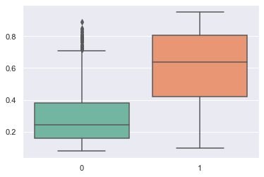

```python
#Boxplot do modelo por probabilidades
sns.boxplot(y_val.ravel(), val_probs)
```

```python
## Salvando o modelo
joblib.dump(lgbmc_tune, 'churn_model_f1_64.sav')
```

```
['churn_model_f1_64.sav']
```

- **Carregando os modelos salvos para conferir.**

```python
## Load model object
model = joblib.load('churn_model_f1_64.sav')
```

```python
## realizando o predict proba e separando apenas as probabilidades de sair 1.
test_probs = model.predict_proba(X_test)[:,1]
```

```python
test_probs
```

```
array([0.50490652, 0.38752278, 0.16519092, ..., 0.12304046, 0.49040345,
       0.36888422])
```

```python
## Faixa de corte, onde todos os valores acima de .48 será churn(1)
test_preds = np.where(test_probs > 0.48, 1, 0)
```

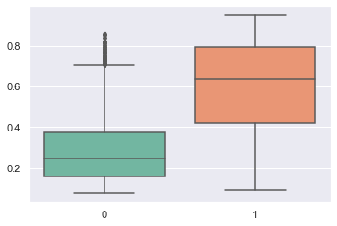

```python
sns.boxplot(y_test.ravel(), test_probs)
```

```python
## resultado no conjunto teste com treshold .48
roc_auc_score(y_test, test_preds)
recall_score(y_test, test_preds)
confusion_matrix(y_test, test_preds)
print(classification_report(y_test, test_preds))
```

```
0.780697463989631
```

```
0.691747572815534
```

```
array([[1381,  207],
       [ 127,  285]], dtype=int64)
```

```
              precision    recall  f1-score   support

           0       0.92      0.87      0.89      1588
           1       0.58      0.69      0.63       412

    accuracy                           0.83      2000
   macro avg       0.75      0.78      0.76      2000
weighted avg       0.85      0.83      0.84      2000
```

### Conclusão do melhor modelo

- **Conclusão**
  - **objetivo:**
    - **F1 = 48**
    - **Recall = 70%**
    - **Precisão = 37%**
- **A Meta principal era encontrar um melhor equilibrio entre o recall e a precisão.**
- **O resultado bateu nosso objetivo, conseguimos uma melhora no f1_score em 16%**
- **Basicamente conseguimos manter o Recall em 70%.**
- **Tivemos uma melhora de 22% de precisão.**
- **Conseguimos um resultado bem satisfatório, agora precisamos demonstrar o resultado de alguma forma.**
- **Para demonstração vamos criar um web-app via streamlit.**

# Pycaret

## Separação do Dataset

```python
# Carregando o dataset
df = pd.read_csv('https://raw.githubusercontent.com/Jcnok/Stack_Labs_Churn/main/Data/Churn_Modelling.csv', index_col='CustomerId')
```

```python
# Dividindo o conjunto em duas partes, uma com 80% e outra com 20%(validação)
split = StratifiedShuffleSplit(test_size=0.8, random_state=777)
```

```python
# com a amostra estratificada as médias das variáveis numéricas ficaram com pouca variância.
for x, y in split.split(df, df['Exited']):
    tr_x = df.iloc[x]
    tr_y = df.iloc[y]
print(tr_x.describe())
print('#'*65)
print(tr_y.describe())
```

```
         RowNumber  CreditScore          Age       Tenure        Balance  \
count  2000.000000  2000.000000  2000.000000  2000.000000    2000.000000
mean   4966.075000   650.091500    39.067500     5.143500   76114.989625
std    2868.330576    93.849667    10.543791     2.903295   62325.661213
min       1.000000   350.000000    18.000000     0.000000       0.000000
25%    2487.750000   586.000000    32.000000     3.000000       0.000000
50%    4953.500000   654.500000    37.000000     5.000000   96939.285000
75%    7437.500000   713.000000    44.000000     8.000000  127763.077500
max    9994.000000   850.000000    84.000000    10.000000  238387.560000

       NumOfProducts    HasCrCard  IsActiveMember  EstimatedSalary  \
count    2000.000000  2000.000000     2000.000000      2000.000000
mean        1.540500     0.708500        0.510500    101825.167495
std         0.588671     0.454567        0.500015     57058.131783
min         1.000000     0.000000        0.000000       143.340000
25%         1.000000     0.000000        0.000000     53404.285000
50%         1.000000     1.000000        1.000000    102239.865000
75%         2.000000     1.000000        1.000000    149868.487500
max         4.000000     1.000000        1.000000    199909.320000

            Exited
count  2000.000000
mean      0.203500
std       0.402702
min       0.000000
25%       0.000000
50%       0.000000
75%       0.000000
max       1.000000
#################################################################
          RowNumber  CreditScore          Age       Tenure        Balance  \
count   8000.000000  8000.000000  8000.000000  8000.000000    8000.000000
mean    5009.106250   650.638125    38.885375     4.980125   76578.614204
std     2891.632715    97.347025    10.474109     2.888646   62418.876272
min        2.000000   350.000000    18.000000     0.000000       0.000000
25%     2504.750000   583.000000    32.000000     2.000000       0.000000
50%     5012.500000   651.000000    37.000000     5.000000   97349.925000
75%     7513.500000   719.000000    44.000000     7.000000  127638.027500
max    10000.000000   850.000000    92.000000    10.000000  250898.090000

       NumOfProducts    HasCrCard  IsActiveMember  EstimatedSalary      Exited
count    8000.000000  8000.000000     8000.000000      8000.000000  8000.00000
mean        1.527625     0.704750        0.516250     99656.507978     0.20375
std         0.579896     0.456184        0.499767     57618.410856     0.40281
min         1.000000     0.000000        0.000000        11.580000     0.00000
25%         1.000000     0.000000        0.000000     50263.057500     0.00000
50%         1.000000     1.000000        1.000000     99677.055000     0.00000
75%         2.000000     1.000000        1.000000    149049.370000     0.00000
max         4.000000     1.000000        1.000000    199992.480000     1.00000
```

[figure not shown]

```python
# visualizando os conjuntos por Churn para confirmar que ambas ficaram equivalentes.
t1 = tr_x.Exited.value_counts()
t2 = tr_y.Exited.value_counts()

plt.figure(1)
plt.subplot(121)
plt.title('treino')
t1.plot.bar()

plt.subplot(122)
plt.title('validação')
t2.plot.bar()
plt.show()
```

- **Bom agora já temos nosso conjunto de treino e de validação, vamos salvar o conjunto de validação, pois ele será utilizado apenas no final do projeto.**

```python
# Vamos Salvar o conjunto de treino e validação
tr_y.to_csv('./treino_base.csv', index=False)
tr_x.to_csv('./validação_base.csv', index=False)
```

- **Bom agora já temos nosso conjunto de treino e validação separados, vamos começar o trabalho.**

```python
#Carregando o modelo de validação
valid = pd.read_csv('https://raw.githubusercontent.com/Jcnok/Stack_Labs_Churn/main/Data/valida%C3%A7%C3%A3o_base.csv', index_col=['CustomerId'])
valid.head()
```

| CustomerId | CreditScore | Geography | Gender | Age | Tenure | Balance | NumOfProducts | HasCrCard | IsActiveMember | EstimatedSalary | Exited |
| --- | --- | --- | --- | --- | --- | --- | --- | --- | --- | --- | --- |
| 15731755 | 680 | France | Male | 49 | 10 | 0.00 | 2 | 1 | 0 | 187008.45 | 0 |
| 15632576 | 520 | France | Male | 31 | 4 | 93249.40 | 1 | 1 | 0 | 77335.75 | 0 |
| 15651955 | 603 | France | Male | 31 | 4 | 0.00 | 2 | 0 | 1 | 9607.10 | 0 |
| 15697310 | 559 | Germany | Female | 28 | 3 | 152264.81 | 1 | 0 | 0 | 64242.31 | 0 |
| 15792360 | 668 | France | Male | 32 | 7 | 0.00 | 2 | 1 | 1 | 777.37 | 0 |

```python
# Carregando o modelo de treino
treino = pd.read_csv('https://raw.githubusercontent.com/Jcnok/Stack_Labs_Churn/main/Data/treino_base.csv', index_col=['CustomerId'])
treino.head()
```

| CustomerId | CreditScore | Geography | Gender | Age | Tenure | Balance | NumOfProducts | HasCrCard | IsActiveMember | EstimatedSalary | Exited |
| --- | --- | --- | --- | --- | --- | --- | --- | --- | --- | --- | --- |
| 15594902 | 518 | France | Male | 38 | 3 | 90957.81 | 1 | 0 | 1 | 162304.59 | 0 |
| 15674551 | 535 | Germany | Male | 40 | 7 | 111756.50 | 1 | 1 | 0 | 8128.32 | 1 |
| 15668695 | 536 | France | Female | 22 | 5 | 89492.62 | 1 | 0 | 0 | 42934.43 | 0 |
| 15748589 | 736 | France | Female | 30 | 9 | 0.00 | 2 | 1 | 0 | 34180.33 | 0 |
| 15771222 | 779 | France | Female | 42 | 5 | 0.00 | 2 | 0 | 0 | 25951.91 | 0 |

## Importando as bibliotecas necessárias para esse trabalho

```python
#importando as libs para a análise.
import pandas as pd
import numpy as np
import matplotlib.pyplot as plt
import seaborn as sns
import plotly.express as px
import warnings
warnings.filterwarnings("ignore")
import missingno as missing
pd.set_option('display.float_format', lambda x: '%.3f' % x)
from pycaret.classification import *
from sklearn.metrics import *
from pycaret.utils import check_metric
%matplotlib inline
```

## Funções

```python
# Função para o conjunto de validação.
def test_score_report(data_unseen, predict_unseen):
    data_unseen["Label"] = data_unseen["Exited"].astype(int)
    accuracy = accuracy_score(data_unseen["Label"], predict_unseen["Label"])
    roc_auc = roc_auc_score(data_unseen["Label"], predict_unseen["Label"])
    precision = precision_score(data_unseen["Label"], predict_unseen["Label"])
    recall = recall_score(data_unseen["Label"], predict_unseen["Label"])
    f1 = f1_score(data_unseen["Label"], predict_unseen["Label"])

    df_unseen = pd.DataFrame({
        "Accuracy" : [accuracy],
        "AUC" : [roc_auc],
        "Recall" : [recall],
        "Precision" : [precision],
        "F1 Score" : [f1]
    })
    return df_unseen
# Confusion Matrix
def conf_mat(data_unseen, predict_unseen):
    unique_label = data_unseen["Label"].unique()
    cmtx = pd.DataFrame(
        confusion_matrix(data_unseen["Label"],
                         predict_unseen["Label"],
                         labels=unique_label),
        index=['{:}'.format(x) for x in unique_label],
        columns=['{:}'.format(x) for x in unique_label]
    )
    ax = sns.heatmap(cmtx, annot=True, fmt="d", cmap="YlGnBu")
    ax.set_ylabel('Predição')
    ax.set_xlabel('Real');
    ax.set_title("Matriz de Confusão do conjunto de Validação", size=14);
```

## Setup do Modelo

```python
# Variáveis ordinárias.
ord_dic ={'NumOfProducts':['1','2','3','4'],
          'Tenure':['0','1','2','3','4','5','6','7','8','9','10']
         }
```

```python
#Criando um setup do pycaret:
model01 = setup(    data=treino,
                      target='Exited',
                      session_id=777,
                      ordinal_features=ord_dic,
                      #ignore_features=# ignore func_def.
                      normalize=True,
                      normalize_method='robust',
                      #transformation= True,
                      #transformation_method= 'quantile',
                      #remove_outliers=True,
                      #outliers_threshold=0.05,
                      #create_clusters= True,
                      #combine_rare_levels= True,
                      #rare_level_threshold=0.05,
                      polynomial_features=True,
                      polynomial_threshold=0.1,
                      #trigonometry_features=True,
                      #feature_interaction = True,
                      #feature_ratio = True,
                      #feature_selection=True,
                      #feature_selection_threshold=0.8,
                      fix_imbalance=True,
                      #fix_imbalance_method=SMOTE,
                      #fold_shuffle = True,
                      data_split_stratify=True,
                      #use_gpu=True,
                      #log_experiment=True,
                      #experiment_name="experimento01",
                      silent=True,
                      verbose=False,
                      #profile=True,
                      #html=True
             )
```

```python
#conjunto de treino transformado.
get_config("X_train").head()
```

| CustomerId | Age | Tenure | Balance | NumOfProducts | EstimatedSalary | CreditScore_Power2 | Age_Power2 | Geography_France | Geography_Germany | Geography_Spain | Gender_Female | HasCrCard_0 | IsActiveMember_1 |
| --- | --- | --- | --- | --- | --- | --- | --- | --- | --- | --- | --- | --- | --- |
| 15571221 | 1.750 | 7.000 | 0.146 | 0.000 | 0.933 | 0.763 | 2.188 | 0.000 | 1.000 | 0.000 | 0.000 | 0.000 | 1.000 |
| 15574206 | 0.000 | 7.000 | -0.764 | 1.000 | -0.438 | 0.521 | 0.000 | 1.000 | 0.000 | 0.000 | 1.000 | 0.000 | 1.000 |
| 15788920 | -0.417 | 4.000 | 0.091 | 1.000 | -0.436 | 1.564 | -0.378 | 0.000 | 1.000 | 0.000 | 1.000 | 0.000 | 0.000 |
| 15680611 | 2.500 | 9.000 | -0.764 | 2.000 | -0.264 | 0.090 | 3.421 | 1.000 | 0.000 | 0.000 | 0.000 | 0.000 | 1.000 |
| 15748116 | -0.667 | 2.000 | 0.396 | 0.000 | -0.469 | 0.227 | -0.579 | 1.000 | 0.000 | 0.000 | 1.000 | 0.000 | 1.000 |

```python
#Criando o modelo lgbm
lightgbm = create_model('lightgbm', optimize_threshold='F1')
```

| Fold | Accuracy | AUC | Recall | Prec. | F1 | Kappa | MCC |
| --- | --- | --- | --- | --- | --- | --- | --- |
| 0 | 0.8214 | 0.8126 | 0.5217 | 0.5714 | 0.5455 | 0.4346 | 0.4353 |
| 1 | 0.8375 | 0.8508 | 0.5351 | 0.6162 | 0.5728 | 0.4731 | 0.4748 |
| 2 | 0.8393 | 0.8516 | 0.6228 | 0.6017 | 0.6121 | 0.5108 | 0.5109 |
| 3 | 0.8464 | 0.8353 | 0.5526 | 0.6429 | 0.5943 | 0.5003 | 0.5025 |
| 4 | 0.8375 | 0.8283 | 0.5526 | 0.6117 | 0.5806 | 0.4802 | 0.4811 |
| 5 | 0.8429 | 0.8572 | 0.5351 | 0.6354 | 0.5810 | 0.4851 | 0.4878 |
| 6 | 0.8518 | 0.8613 | 0.5088 | 0.6824 | 0.5829 | 0.4951 | 0.5030 |
| 7 | 0.8750 | 0.8926 | 0.6140 | 0.7292 | 0.6667 | 0.5904 | 0.5937 |
| 8 | 0.8429 | 0.8474 | 0.5263 | 0.6383 | 0.5769 | 0.4815 | 0.4849 |
| 9 | 0.8479 | 0.8550 | 0.5614 | 0.6465 | 0.6009 | 0.5076 | 0.5095 |
| Mean | 0.8443 | 0.8492 | 0.5531 | 0.6375 | 0.5914 | 0.4959 | 0.4984 |
| Std | 0.0129 | 0.0203 | 0.0360 | 0.0416 | 0.0303 | 0.0376 | 0.0381 |

```python
# Realizando a predição
predict_model(lightgbm);
```

|  | Model | Accuracy | AUC | Recall | Prec. | F1 | Kappa | MCC |
| --- | --- | --- | --- | --- | --- | --- | --- | --- |
| 0 | Light Gradient Boosting Machine | 0.8546 | 0.8648 | 0.5706 | 0.6675 | 0.6152 | 0.5263 | 0.5287 |

- **Validação**

|  | Model | Accuracy | AUC | Recall | Prec. | F1 | Kappa | MCC |
| --- | --- | --- | --- | --- | --- | --- | --- | --- |
| 0 | Light Gradient Boosting Machine | 0.8455 | 0.8558 | 0.5872 | 0.6289 | 0.6074 | 0.5113 | 0.5118 |

```
 Accuracy   AUC  Recall  Precision  F1 Score
    0.846 0.749   0.587      0.629     0.607
```

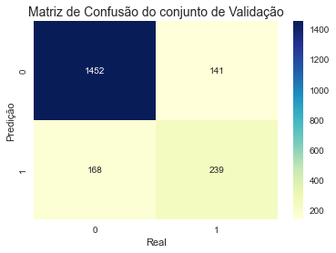

```python
predict_valid = predict_model(lightgbm, data=valid);
score_valid = test_score_report(valid, predict_valid)
print(score_valid.to_string(index=False))
conf_mat(valid, predict_valid)
```

## Tunagem Pycartet

```python
lgbm_tune = tune_model(lightgbm,
                              optimize = 'F1',
                              search_library='scikit-optimize',
                              search_algorithm='bayesian'
                             )
```

| Fold | Accuracy | AUC | Recall | Prec. | F1 | Kappa | MCC |
| --- | --- | --- | --- | --- | --- | --- | --- |
| 0 | 0.8089 | 0.8186 | 0.5739 | 0.5323 | 0.5523 | 0.4311 | 0.4316 |
| 1 | 0.8286 | 0.8568 | 0.6579 | 0.5682 | 0.6098 | 0.5007 | 0.5029 |
| 2 | 0.8286 | 0.8412 | 0.6579 | 0.5682 | 0.6098 | 0.5007 | 0.5029 |
| 3 | 0.8446 | 0.8427 | 0.6228 | 0.6174 | 0.6201 | 0.5224 | 0.5225 |
| 4 | 0.8214 | 0.8352 | 0.5877 | 0.5583 | 0.5726 | 0.4599 | 0.4601 |
| 5 | 0.8464 | 0.8588 | 0.6053 | 0.6273 | 0.6161 | 0.5201 | 0.5203 |
| 6 | 0.8429 | 0.8701 | 0.5965 | 0.6182 | 0.6071 | 0.5090 | 0.5091 |
| 7 | 0.8696 | 0.9054 | 0.7018 | 0.6723 | 0.6867 | 0.6044 | 0.6047 |
| 8 | 0.8500 | 0.8608 | 0.6140 | 0.6364 | 0.6250 | 0.5313 | 0.5314 |
| 9 | 0.8336 | 0.8468 | 0.5877 | 0.5929 | 0.5903 | 0.4859 | 0.4859 |
| Mean | 0.8375 | 0.8536 | 0.6205 | 0.5991 | 0.6090 | 0.5065 | 0.5071 |
| Std | 0.0161 | 0.0222 | 0.0382 | 0.0404 | 0.0337 | 0.0436 | 0.0435 |

- **Validação**

|  | Model | Accuracy | AUC | Recall | Prec. | F1 | Kappa | MCC |
| --- | --- | --- | --- | --- | --- | --- | --- | --- |
| 0 | Light Gradient Boosting Machine | 0.8410 | 0.8556 | 0.6609 | 0.5991 | 0.6285 | 0.5277 | 0.5287 |

```
 Accuracy   AUC  Recall  Precision  F1 Score
    0.841 0.774   0.661      0.599     0.629
```

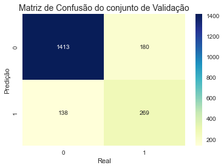

```python
predict_valid = predict_model(lgbm_tune, data=valid);
score_valid = test_score_report(valid, predict_valid)
print(score_valid.to_string(index=False))
conf_mat(valid, predict_valid)
```

- **Predict com o conjunto todo.**

```python
predict_all = predict_model(lgbm_tune, data=df);
```

|  | Model | Accuracy | AUC | Recall | Prec. | F1 | Kappa | MCC |
| --- | --- | --- | --- | --- | --- | --- | --- | --- |
| 0 | Light Gradient Boosting Machine | 0.8456 | 0.8641 | 0.6465 | 0.6151 | 0.6304 | 0.5329 | 0.5332 |

```python
print(classification_report(predict_all.Exited,predict_all.Label))
```

```
              precision    recall  f1-score   support

           0       0.91      0.90      0.90      7963
           1       0.62      0.65      0.63      2037

    accuracy                           0.85     10000
   macro avg       0.76      0.77      0.77     10000
weighted avg       0.85      0.85      0.85     10000
```

- **Salvando o modelo**

```python
#Salvando o modelo
save_model(lgbm_tune,'lgbm_tune_pycaret')
```

```
Transformation Pipeline and Model Successfully Saved
```

```
(Pipeline(memory=None,
          steps=[('dtypes',
                  DataTypes_Auto_infer(categorical_features=[],
                                       display_types=False, features_todrop=[],
                                       id_columns=[],
                                       ml_usecase='classification',
                                       numerical_features=[], target='Exited',
                                       time_features=[])),
                 ('imputer',
                  Simple_Imputer(categorical_strategy='not_available',
                                 fill_value_categorical=None,
                                 fill_value_numerical=None,
                                 numeric_stra...
                                 learning_rate=0.06699588304420269, max_depth=-1,
                                 min_child_samples=76, min_child_weight=0.001,
                                 min_split_gain=0.4450203221860495,
                                 n_estimators=129, n_jobs=-1, num_leaves=5,
                                 objective=None, optimize_threshold='F1',
                                 random_state=777,
                                 reg_alpha=5.172619707249412e-07,
                                 reg_lambda=1.5785605569240774e-05,
                                 silent='warn', subsample=1.0,
                                 subsample_for_bin=200000, subsample_freq=0)]],
          verbose=False),
 'lgbm_tune_pycaret.pkl')
```

- **Conferindo o modelo Salvo.**

```python
#conferindo o modelo salvo
modelo = load_model('./lgbm_tune_pycaret')
```

```
Transformation Pipeline and Model Successfully Loaded
```

```python
#Predição do conjunto para conferir
predito = modelo.predict(valid)
```

```python
# report do resultado.
print(classification_report(valid.Exited,predito))
```

```
              precision    recall  f1-score   support

           0       0.91      0.89      0.90      1593
           1       0.60      0.66      0.63       407

    accuracy                           0.84      2000
   macro avg       0.76      0.77      0.76      2000
weighted avg       0.85      0.84      0.84      2000
```

## Conclusão modelo pycaret_tunado

```python
# report do resultado.
print(classification_report(valid.Exited,predito))
```

```
              precision    recall  f1-score   support

           0       0.91      0.89      0.90      1593
           1       0.60      0.66      0.63       407

    accuracy                           0.84      2000
   macro avg       0.76      0.77      0.76      2000
weighted avg       0.85      0.84      0.84      2000
```

- **Conclusão**
  - **objetivo:**
    - **F1 = 48**
    - **Recall = 70%**
    - **Precisão = 37%**
- **A Meta principal era encontrar um melhor equilibrio entre o recall e a precisão.**
- **O resultado bateu nosso objetivo, conseguimos uma melhora no f1_score em 15%**
- **O Recall em 66% um pouco a baixo do modelo base, porém com uma melhora significativa na precisão e f1 score.**
- **Tivemos uma melhora de 23% de precisão.**
- **Conseguimos um bom desempenho, entre precisão e recall, com uma acurácia de 84%.**
- **Se no modelo base tinhamos um acerto de 4 a cada 10 agora conseguimos encontrar 6 clientes a cada 10.**
- **Valor que o banco perdeu em capitalização por conta dos clientes que cancelaram.**

```python
#Total real de churn
churn_balance = df.query('Exited ==1')
churn_balance['Balance'].sum()
```

```
185588094.63
```

- **Vamos pegar 66% o nosso recall desse conjunto de forma aleatória**

```python
#Pegando 66¨% do total de churn de forma aleatória
recall_66 = churn_balance.sample(frac=.66)
recall_66.shape
```

```
(1344, 13)
```

- **Agora vamos saber o quanto em capitalização esses 66% representam em média**

```python
recall_66['Balance'].sum()
```

```
122943097.71000001
```

- **Podemos dizer que meu modelo consegue prever 66% do conjunto com uma precisão de 60%**.
- **E que esses clientes representam uma perde de reserva 122.943.097,71 milhões de Euros.**
- **Óbviamente que por mais que tenhamos uma lista bem reduzida de clientes com grandes possibilidades de churn, e mesmo como uma excelente estratégia de retenção, não será possível reter grande parte da lista, porém, vamos supor que a taxa média fique em 5%.**
- **Quanto em termos de valores represantam esses 5%?**

```python
# Separando uma amostra de 5% de forma aleatória
recall_66.sample(frac=.05)['Balance'].sum()
```

```
6031348.850000001
```

- **Em termos de valores ficaria algo em torno de 6.031.348,85 Euros que o banco estaria deixando de perder.**
- **Vale lembra que isso é apenas uma exemplo, sabemos que exitem custos embutidos gera um impacto direto nesses resultados, mas a grosso modo podemos entender o valor da análise.**

```python
df.Balance.sum()
```

```
764858892.8800001
```

```python
(6031348.850000001 / 764858892.8800001) * 100
```

```
0.7885570666884131
```